# Proyecto SNV1

# Justificación de los resultados

Como los resultados del ajuste parecen tan buenos, se buscarán razones por las que esto pueda pasar.

Inicialmente, se muestra el porcentaje de incendios y de no incendios en los datos disponibles.

```r
# DataFrame con el porcentaje de incendios
porcentaje.incendios <-
  data.frame(porcentaje = c((
    sum(incendios$Classes == "Incendio") / nrow(incendios)
  ), 1 - (
    sum(incendios$Classes == "Incendio") / nrow(incendios)
  )),
  clase = c("Incendio", "No incendio"))

# Se imprime para ver los valores exactos
porcentaje.incendios
```

```
##   porcentaje       clase
## 1   0.563786    Incendio
## 2   0.436214 No incendio
```

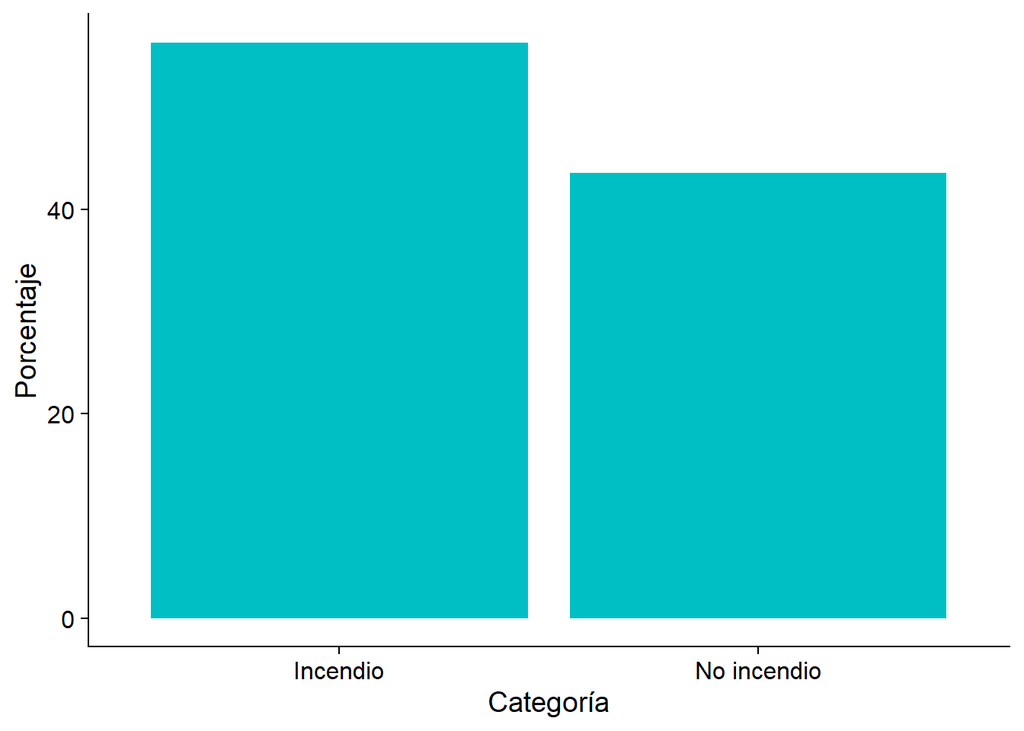

```r
# Gráfico de los porcentajes
ggplot(porcentaje.incendios, aes(x = clase, y = porcentaje * 100)) +
  geom_bar(stat = "identity", fill = "#00BFC4") +
  labs(x = "Categoría", y = "Porcentaje") +
  theme_cowplot()
```

En este gráfico se observa que ambas categorías están bastante balanceadas, lo cual suele favorecer el rendimiento de los modelos de clasificación.

Esto se observa debido a que, se ha demostrado, que el desequilibrio entre clases puede influir negativamente en el entrenamiento de un modelo. A continuación la cita:

@article{BM18, issn = {0893-6080}, journal = {Neural networks}, volume = {106}, publisher = {Elsevier Ltd}, year = {2018}, title = {A systematic study of the class imbalance problem in convolutional neural networks}, author = {Buda, Mateusz and Maki, Atsuto and Mazurowski, Maciej A.}, DOI = {https://doi.org/10.1016/j.neunet.2018.07.011} }

Luego, otro factor que puede afectar a la clasificación son las variables predictoras. En este caso, existe la posibilidad de que una variable, individualmente, distinga la clase que se quiere predecir. A continuación se hace el análisis con las variables de mayor importancia para los modelos.

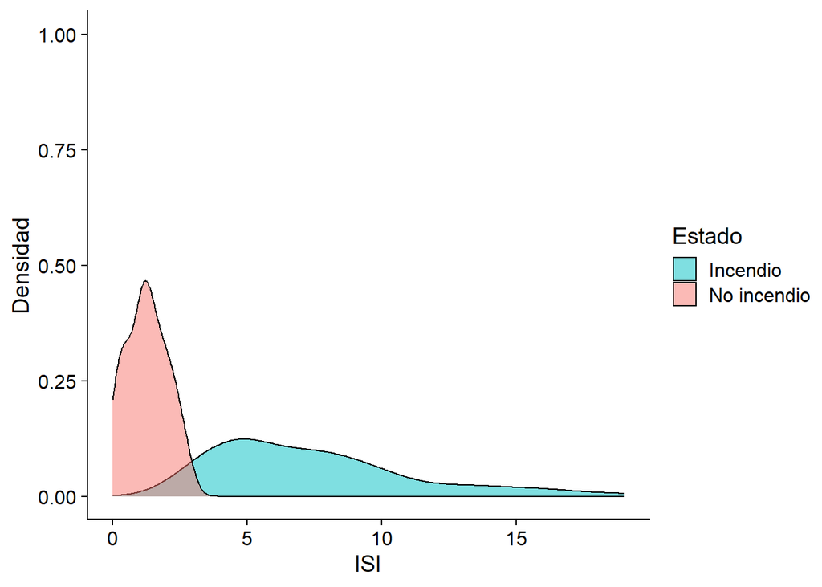

```r
# Gráfico de densidad del ISI separado por variable predictora
ggplot(incendios, aes(x = ISI, fill = Classes)) +
  geom_density(alpha = 0.5, position = "identity") +
  scale_y_continuous(limits = c(0, 1)) +
  scale_fill_manual(
    values = c("Incendio" = "#00BFC4", "No.incendio" = "#F8766D"),
    labels = c("fire" = "Incendio", "No.incendio" = "No incendio"),
    name = "Estado"
  ) +
  labs(x = "ISI",
       y = "Densidad") +
  theme_cowplot()
```

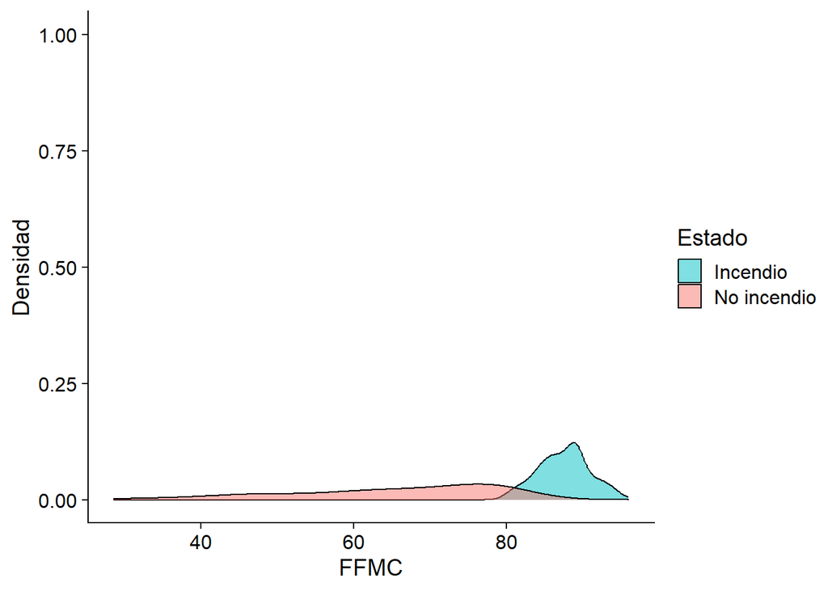

```r
# Gráfico de densidad del FFMC separado por variable predictora
ggplot(incendios, aes(x = FFMC, fill = Classes)) +
  geom_density(alpha = 0.5, position = "identity") +
  scale_y_continuous(limits = c(0, 1)) +
  scale_fill_manual(
    values = c("Incendio" = "#00BFC4", "No.incendio" = "#F8766D"),
    labels = c("fire" = "Incendio", "No.incendio" = "No incendio"),
    name = "Estado"
  ) +
  labs(x = "FFMC",
       y = "Densidad") +
  theme_cowplot()
```

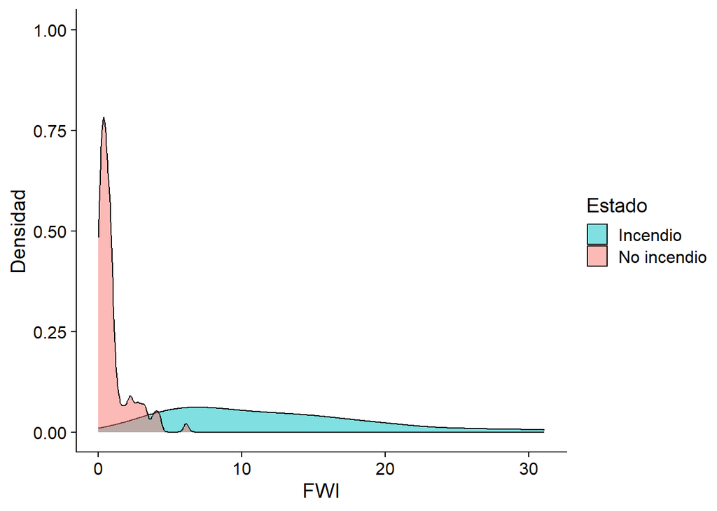

```r
# Gráfico de densidad del FWI separado por variable predictora
ggplot(incendios, aes(x = FWI, fill = Classes)) +
  geom_density(alpha = 0.5, position = "identity") +
  scale_y_continuous(limits = c(0, 1)) +
  scale_fill_manual(
    values = c("Incendio" = "#00BFC4", "No.incendio" = "#F8766D"),
    labels = c("fire" = "Incendio", "No.incendio" = "No incendio"),
    name = "Estado"
  ) +
  labs(x = "FWI",
       y = "Densidad") +
  theme_cowplot()
```

En los 3 casos anteriores, se puede ver una clara separación entre los casos en donde ocurre el incendio y en los que no sucede, con una única variable. Esto indica que estos factores son buenos discriminadores con respecto al estado del suceso.

En diversos estudios se señala la importancia de seleccionar estas variables. Más aún; algoritmos como *Random forest* se suelen utilizar para escoger dichas variables (cita que está abajo). Lo cual explica por qué se da un rendimiento tan elevado en los modelos propuestos.

@article{CR20, issn = {2196-1115}, journal = {Journal of big data}, volume = {7}, publisher = {Springer International Publishing}, number = {1}, year = {2020}, title = {Selecting critical features for data classification based on machine learning methods}, author = {Chen, Rung-Ching and Dewi, Christine and Huang, Su-Wen and Caraka, Rezzy Eko}, DOI = {https://doi.org/10.1186/s40537-020-00327-4} }